# Applications of Inference Frameworks: Difference of Means

## Horned lizard predation

[figure not shown]

## Horned lizard predation

```r
HL <- read_csv("../data/HornedLizards.csv")
glimpse(HL)
```

```
## Rows: 185
## Columns: 2
## $ horn_length <dbl> 25.2, 26.9, 26.6, 25.6, 25.7, 25.9, 27.3, 25.1, 30.3, 25.…
## $ group       <chr> "alive", "alive", "alive", "alive", "alive", "alive", "al…
```

```r
HL %>% group_by(group) %>% tally()
```

```
## # A tibble: 2 x 2
##   group     n
##   <chr> <int>
## 1 alive   155
## 2 dead     30
```

## Horned lizard predation

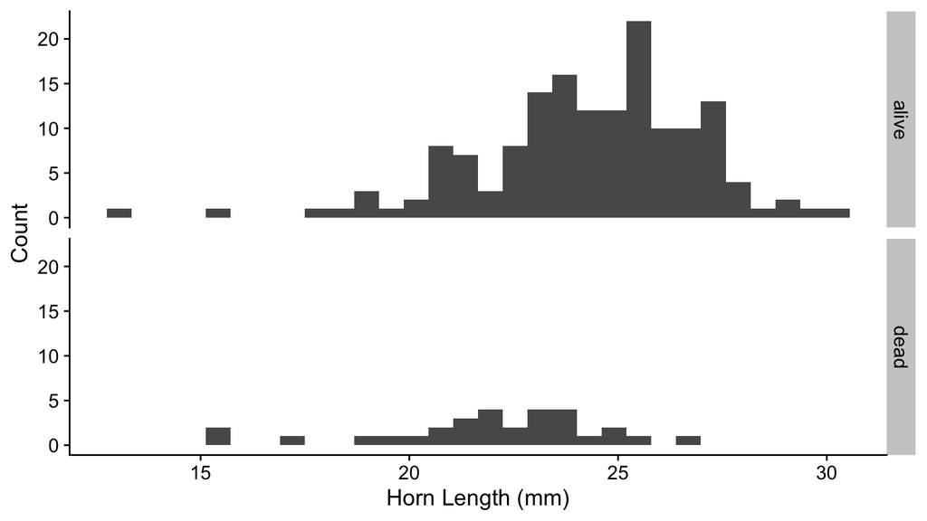

## Summarize

```r
HL %>% group_by(group) %>%
  summarize(horn_mean = mean(horn_length),
            horn_sd = sd(horn_length))
```

```
## # A tibble: 2 x 3
##   group horn_mean horn_sd
##   <chr>     <dbl>   <dbl>
## 1 alive      NA     NA
## 2 dead       22.0    2.71
```

```r
sum(!complete.cases(HL))
```

```
## [1] 1
```

## Summarize

Drop rows with any `NA`s:

```r
HL <- HL %>% drop_na()
```

Summarize:

```r
HL %>% group_by(group) %>%
  summarize(horn_mean = mean(horn_length),
            horn_sd = sd(horn_length))
```

```
## # A tibble: 2 x 3
##   group horn_mean horn_sd
##   <chr>     <dbl>   <dbl>
## 1 alive      24.3    2.63
## 2 dead       22.0    2.71
```

## Are the means different?

Horn length in live horned lizards: 24.28 mm

Horn length in dead horned lizards: 21.99 mm

Imagine you collected 100 live horned lizards and randomly assigned 50 to each of two groups. Do you think they would have the same mean horn length? How different do you think the means would be? Think about how the variability among individual horn length measurements would affect your intuition here.

> The first principle is that you must not fool yourself – and you are the easiest person to fool. -Feynman

## How large of a difference do we expect to see from sampling error?

[figure not shown]

- Imagine a distribution of horn lengths for a population of horned lizards (mean = 24, sd = 3)
- Randomly catch two groups of \(n = 50\) from this population
- How different are the groups?

## How large of a difference do we expect to see from sampling error?

```r
set.seed(883231)
mu.horn <- 24   # mean
sd.horn <- 3    # standard deviation
n.iter <- 10000 # number of iterations
n.samp <- 50    # number in each sample
sim.diff <- tibble(dd = numeric(length = n.iter)) # to hold for output

for (zz in 1:n.iter) {
  s1 <- rnorm(n.samp, mu.horn, sd.horn) # sample 1
  s2 <- rnorm(n.samp, mu.horn, sd.horn) # sample 2
  sim.diff[zz, 'dd'] <- mean(s1) - mean(s2) # difference in means
}
```

## How large of a difference do we expect to see from sampling error?

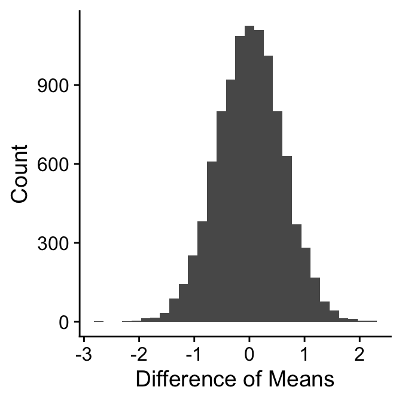

- Imagine a distribution of horn lengths for a population of horned lizards (mean = 24, sd = 3)
- Randomly catch two groups of \(n = 50\) from this population
- How different are they?

## How large of a difference do we expect to see from sampling error?

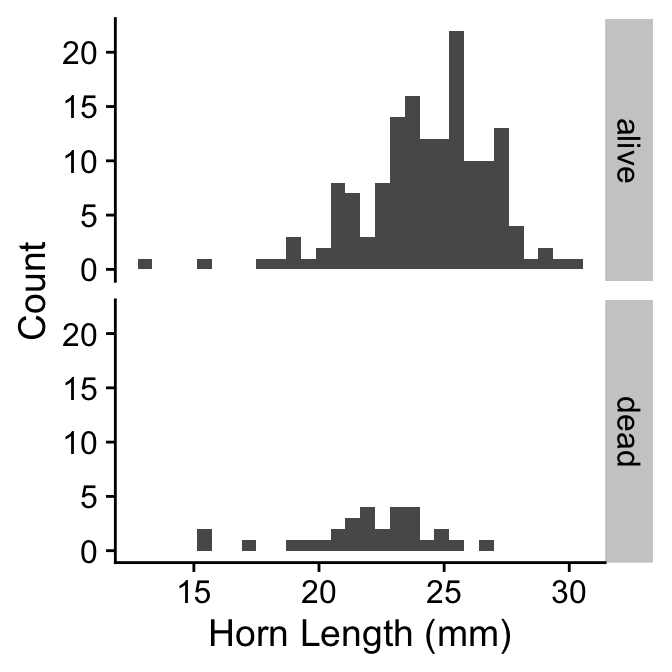

Horn length in live horned lizards: 24.28 mm

Horn length in dead horned lizards: 21.99 mm

Difference: 2.29

Are the means different?

## How large of a difference do we expect to see from sampling error?

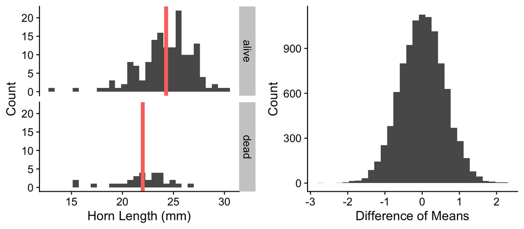

Difference = 2.29 mm

## Frameworks for inference

1. Analytical
2. Maximum likelihood
3. Resampling
4. Bayesian

## Analytical: *t*-test

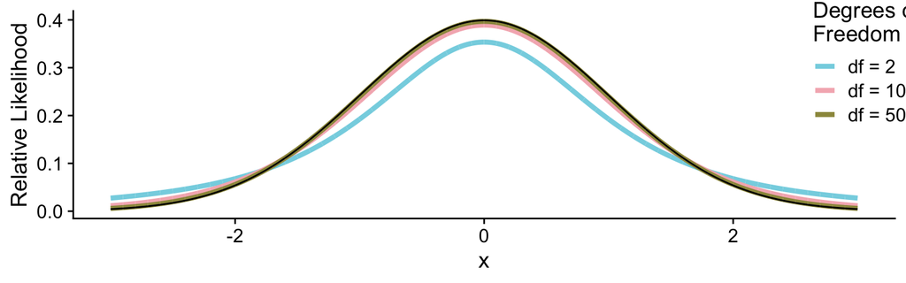

- Test statistic based on means, standard deviations, and sample size
- Follows a *t* distribution
- Like a normal distribution that accounts for sample size
- We won’t derive the *t* distribution

## *t*-test

```r
t.test(horn_length ~ group, data = HL, var.equal = TRUE)
```

```
##
##  Two Sample t-test
##
## data:  horn_length by group
## t = 4.3494, df = 182, p-value = 2.27e-05
## alternative hypothesis: true difference in means is not equal to 0
## 95 percent confidence interval:
##  1.253602 3.335402
## sample estimates:
## mean in group alive  mean in group dead
##            24.28117            21.98667
```

## Frameworks for inference

1. Analytical
2. Maximum likelihood
3. Resampling
4. Bayesian